# NCBN Salt Marsh Vegetation Monitoring Protocol Review

#### **1. Introduction**

##### **1.1** The NCBN Salt Marsh Vegetation Monitoring Protocol

The National Park Service Inventory and Monitoring (I&M) Program’s Northeast Coastal and Barrier Network (NCBN) has identified salt marsh condition, in addition to several associated vital signs, as a high priority for long-term monitoring. The first iteration of the salt marsh vegetation monitoring protocol was originally developed by the USGS and University of Rhode Island for the purpose of comparing the vegetation community in hydrologically altered marshes to more pristine “control” marshes in order to understand the potential effects of hydrologic restoration on salt marsh habitats within Cape Cod National Seashore (Roman et al., 2001). This protocol was then adapted to measure change in the species composition and abundance of the salt marsh plant community at the other six coastal parks monitored by NCBN in response to a multitude of stressors such as hydrologic alteration, storms, visitor use, nutrient loading, watershed development, sea-level rise, and climate change, among others (Rocks and Stevens 2018). The salt marsh vegetation monitoring protocol was successfully implemented across seven NCBN parks over a period of 10 years from 2008 to 2018 but was placed on hold in 2018 due to staffing and budget shortages. Several annual summary reports were published for each park while the protocol was active, including reports for Assateague Island National Seashore (2008, 2010, 2012, and 2014), Cape Cod National Seashore (2003, 2008, and 2013), Colonial National Historical Park (2008, 2010, 2012, and 2014), Fire Island National Seashore (2009, 2011, and 2015), Gateway National Recreation Area (2010, 2012, and 2014), George Washington Birthplace National Monument (2008, 2010, and 2012), and Sagamore Hill National Historical Site (2009, 2011, and 2015) (DataStore saved search: 3465). To date, only a single trend analysis of the existing data has been conducted (Peck et al. 2021). Since this protocol was put on hold in 2018, resource management staff at several parks in the NCBN network have expressed interest in both the results of the previous monitoring efforts and in continued salt marsh vegetation monitoring at their respective parks. Thus, the objectives of this report are a) identify limitations of the current protocol and previous trend analyses conducted by Peck et al. (2021); b) provide additional analysis of the existing data and interpretation of the results that may be useful to the parks’ resource management staff; and c) discuss alternative methods for continued monitoring of salt marsh vegetation in the parks.

##### **1.2** Limitations of the Current Protocol

During the years that this protocol was active, it was by far the most labor- and time-intensive vital sign monitored by NCBN. For instance, assuming a four-person crew (two full-time biologists and two interns) was used for each sampling event, a conservative estimate of 7,072 total man-hours were dedicated to field data collection alone during this time (i.e., 221 sampling events x 8 hours per day x 4 crew members). Furthermore, this estimate does not include the additional time needed for traveling to and from the NCBN main office (Kingston, Rhode Island) to each park, logistical considerations (e.g., time for budget and travel planning, equipment preparation, clean-up, etc.), or data management and reporting tasks, among others. For a more specific example, it took a total of 13 full days to complete field sampling at just one park - ASIS - in 2018. Similarly, this protocol was also one of the more budget intensive monitoring programs conducted by NCBN. In 2018, Rocks and Stevens (2018) estimated that the annual operational cost associated with the NCBN salt marsh vegetation monitoring protocol was $50,000 per year - a figure that would likely be much higher today. Thus, budget and staffing shortages represent a major impediment to continuing the field data collection procedures as outlined in the existing protocol.  
The data summaries that were suggested for annual reporting in the protocol implementation plan (Rocks and Stevens 2018) include species composition (species lists), percent cover for all cover types by site, and presence of any federal, state-listed and/or non-native species. Additionally, the protocol implementation plan also recommends that trend analysis be conducted on a 3- to 5-year basis and suggests the use of non-parametric multivariate community analysis methods such as analysis of similarities (ANOSIM) and similarity of percentages analysis (SIMPER) in order to understand change over time. The suggestion to include species lists for annual reporting are necessary in order to have a record of the full suite of species at each park and the compilation of these lists is relatively straightforward and easy to interpret. However, the recommended trend analysis (ANOSIM and SIMPER) does not actually calculate trends and can only indicate where differences between plant communities have occurred between pairs of the sample events. As such, these methods of analysis have limited value for understanding the broader “big picture” changes in these salt marsh plant communities and also do not provide a means for predicting future changes and developing management actions that may be needed to either counteract or facilitate these changes.

##### **1.3** Limitations of Previous Analyses

In 2021, NCBN commissioned a report by Neptune and Company (hereafter referred to as Peck et al. 2021) that evaluates the sampling power of the salt marsh vegetation and nekton monitoring protocols and summarizes trends within a limited subset of the metrics collected as part of these protocols. For the vegetation protocol, the metrics of interest were a multimetric index (MMI) of salt marsh condition developed by Nagel et al. (2017), as well as individual metrics of community composition including the percent cover of Spartina patens and percent cover of high salinity plant species. Power simulations were performed to assess whether the data collected to date were sufficient to detect trends in either the multimetric index or previously listed individual metrics given the large amount of staff time and program money being spent on these protocols. Trends in the multimetric index and the two selected individual metrics for the period of 2008 to 2018 were also quantified using regression analyses. In this section, we have summarized the findings of Peck et al. (2021) and identified limitations of the study that could potentially be addressed by performing additional analyses on the existing data from 2008-2018.

There are two limited conclusions that can be drawn from both a simple visual inspection of the plots showing how each measure changed over the study period (report figures 6-11) and results of the generalized linear models (report tables 3-8): 1) the selected metrics of vegetation community composition show no change at most parks, and 2) of the metrics that do have statistically significant rates of change (Spartina patens cover at FIIS and high salinity plant species cover at FIIS), the magnitude of these changes is relatively small. The findings of Peck et al. (2021) are largely consistent with other similar monitoring studies that found that vegetation communities that are responding to long-term factors, like sea-level rise and climate change, as opposed to dramatic hydrologic alterations or discrete disturbance events (e.g., hurricanes), are likely to see changes that occur over decades or centennial time scales (Roman et al. 1997; Warren and Niering 1993). Additionally, for the measures that showed no change at some or all parks, changes in these communities could be occurring at extremely subtle rates that may not be discernible over the relatively short 10-year period that the vegetation and nekton monitoring protocols were active. Similarly, this previous analysis examined only a subset of the data collected for this protocol and does not include many of the trend analyses that may be directly applicable to resource management in the parks. Although Peck et al. (2021) has value as both an assessment of the protocol’s sampling frequency and intensity and as an initial exploratory data analysis, there are large amounts of data that were collected for the salt marsh vegetation monitoring protocol that were not examined in the report. For example, the protocol necessitates recording the presence and cover of every individual species found in every plot, but only a few species are used in the analyses. As such, the analyses contained within Peck et al. (2021) did not consider changes within the context of either a) ecologically significant groups that are known to characterize these habitats, or b) the entire full, comprehensive suite of species that comprise these communities. Given the multivariate nature of the data and the protocol’s focus on monitoring change in biological communities over time, this report includes several additional analyses that could aid in interpreting and drawing conclusions from the existing 2008-2018 data set in the following sections. The methods and results of these additional analyses are provided in the following sections.

Finally, Peck et al. (2021) suggested that the current sampling intensity and frequency are not high enough to detect a true difference in many of the metrics of interest at most parks. Sampling efforts varied greatly between the parks due to differences in the areal extent of salt marsh habitats at each park. However, given that sampling efforts at each park are limited by logistical constraints that are not within NCBN’s control, such as staff availability, travel funds, weather, and site access challenges, it is unlikely that NCBN would have the bandwidth to increase sampling effort as suggested by Peck et al. (2021). Since several recent studies using remote sensing for ecological monitoring have demonstrated great promise as an alternative to time-consuming and expensive on-the-ground surveys (DiGiacomo et al. 2022, Harris et al. 2024, Myers et al. 2018, Nardin et al. 2021, Puckett et al., Routhier et al. 2023), we have utilized the final section of this report to discuss the possibility of applying these techniques to the salt marsh vegetation monitoring protocol as an alternative method that would allow NCBN to continue providing this valuable information to the parks given current logistical and budget constraints.

#### **2. Methods**

##### **2.1** Details of Park-Specific Sampling Schemes

Assateague Island National Seashore is a barrier island on the Atlantic Coasts of Maryland (Worchester County) and Virginia (Accomack County) that consists of beach, dune, and back-barrier marsh habitats. Nine sites were monitored biannually across six sampling events between 2008 to 2018 at a total of 450 plots (Figure 1a).  
At Cape Cod National Seashore, ten sites were monitored between 1997 to 2013. However, these sites were not monitored consistently across the same years because the study plan at this park was designed specifically for monitoring change at individual sites (rather than the entire park) following several different planned restoration projects. Given the difference in the study design as compared to the other six parks, we have excluded the data from Cape Cod from this analyses, although note that the park has published a monitoring report summarizing the monitoring data from 2003, 2008, and 2013 (Smith, 2015).  
Colonial National Historical Park lies within the Atlantic Coastal Plain (York County, Virginia) and is bisected by the York and James Rivers which feed into the Chesapeake Bay. Although the majority (80%) of the managed area at Colonial is comprised of upland pine and hardwood forest, wetland habitats within the park include streams, ponds, swamps, and marshes. Eight sites consisting of 400 plots were monitored across five sampling events between 2008 to 2016 (Figure 1b). However, sites C1, C5, C6, and C8 were measured between 2008 and 2010, but were then replaced by sites C5, C13, C19, C23, and C30 in 2012, 2014, and 2016 due to time and access constraints.  
Fire Island National Seashore is a barrier island on the Atlantic Coast of Long Island (Suffolk County, New York) that consists of beach, dune, maritime forest, and back-barrier marsh habitats. Nine sites were monitored biannually across five sampling events between 2009 to 2017 at a total of 450 plots (Figure 1c), with the exception of site F6 which was not measured in 2013.  
Gateway National Recreation Area consists of three units including the Jamaica Bay unit in Brooklyn (New York), the Staten Island unit (New York), and the Sandy Hook unit (Monmouth County, New Jersey), however only the Sandy Hook unit was sampled as part of the NCBN salt marsh vegetation monitoring protocol. The Sandy Hook unit consists of a sand spit with beach, dune, and back-barrier marsh habitats. Three sites were monitored biannually across five sampling events between 2010 to 2018 at a total of 150 plots (Figure 1d). However, note that only site one site - GSH1 - was measured in 2014.  
George Washington Birthplace National Monument sits at the confluence of Popes Creek and the Potomac River (Westmoreland County, Virginia) and includes wetland habitats such as coastal hardwood forests, beaches, dunes, and marshes. Only one site was measured biannually across three sampling events between 2008 to 2012 at a total of 50 plots (Figure 1e).  
Sagamore Hill National Historic Site is located adjacent to Cold Spring Harbor on the Cove Neck Peninsula in eastern Long Island (New York). Coastal wetland habitats in the park include coastal forests, dunes, and salt marshes. Only one site was measured biannually across five sampling events between 2009 to 2017 at a total of 50 plots (Figure 1f).  
Note that parks will be referred to with their respective four-letter unit codes throughout the remainder of the text (Table 1). Additional details of the sampling design used at each park are presented in Table 1.

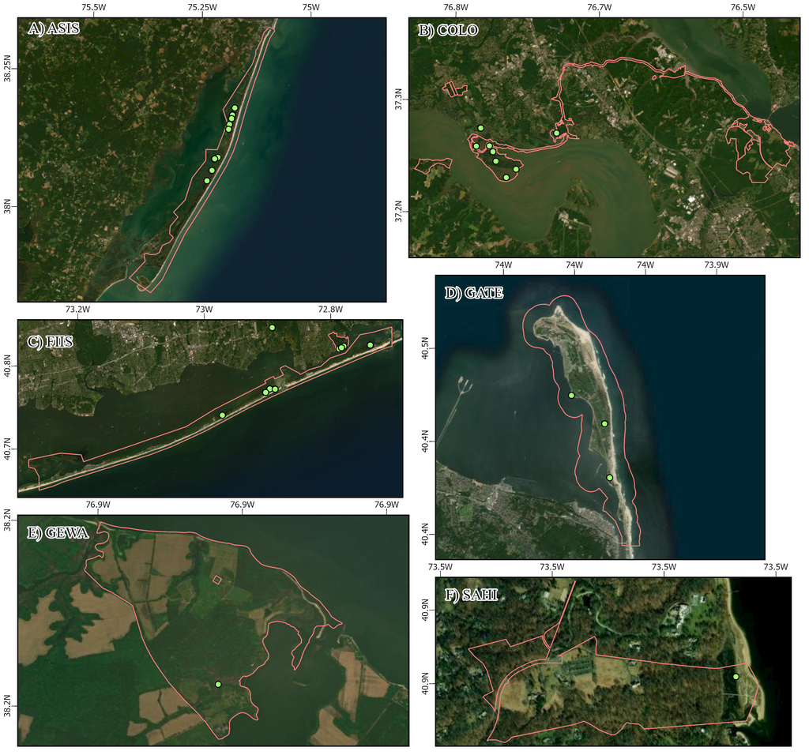

| Table 1. Site count, plot count, monitoring years, and count of sampling events at each park utilizing the NCBN salt marsh vegetation monitoring protocol. Park | Table 1. Site count, plot count, monitoring years, and count of sampling events at each park utilizing the NCBN salt marsh vegetation monitoring protocol. Unit Code | Table 1. Site count, plot count, monitoring years, and count of sampling events at each park utilizing the NCBN salt marsh vegetation monitoring protocol. Location | Table 1. Site count, plot count, monitoring years, and count of sampling events at each park utilizing the NCBN salt marsh vegetation monitoring protocol. Number of Sites | Table 1. Site count, plot count, monitoring years, and count of sampling events at each park utilizing the NCBN salt marsh vegetation monitoring protocol. Site List | Table 1. Site count, plot count, monitoring years, and count of sampling events at each park utilizing the NCBN salt marsh vegetation monitoring protocol. Number of Plots | Table 1. Site count, plot count, monitoring years, and count of sampling events at each park utilizing the NCBN salt marsh vegetation monitoring protocol. Sample Years | Table 1. Site count, plot count, monitoring years, and count of sampling events at each park utilizing the NCBN salt marsh vegetation monitoring protocol. Sampling Events |
| --- | --- | --- | --- | --- | --- | --- | --- |
| Assateague Island National Seashore | ASIS | MD, VA | 9 | A10, A11, A2, A3, A4, A5, A6, A8, A9 | 450 | 2008, 2010, 2012, 2014, 2016, 2018 | 6 |
| Colonial National Historical Park | COLO | VA | 8 | C1, C13, C19, C23, C30, C5, C6, C8 | 400 | 2008, 2010, 2012, 2014, 2016 | 5 |
| Fire Island National Seashore | FIIS | NY | 9 | F1, F2, F3, F4, F5, F6, WF1, WF2, WF3 | 450 | 2009, 2011, 2013, 2015, 2017 | 5 |
| Gateway National Recreation Area | GATE | NJ, NY | 3 | GSH1, GSH2, GSH3 | 150 | 2010, 2012, 2014, 2016, 2018 | 5 |
| George Washington Birthplace National Monument | GEWA | VA | 1 | G1 | 50 | 2008, 2010, 2012 | 3 |
| Sagamore Hill National Historic Site | SAHI | NY | 1 | SAG1 | 50 | 2009, 2011, 2013, 2015, 2017 | 5 |

##### **2.2** Additional Analyses of the 2008-2018 Data

The salt marsh plant community at each park was assessed by visually estimating the percent cover of each species within 50 replicate 1 m<sup>2</sup> plots that were randomly established within each of 1-9 sites at each park during each sampling event (Table 1). Prior to analyses, the percent cover of each species in each plot was averaged up to the site-level as outlined in SOP 7 of the NCBN Salt Marsh Vegetation Monitoring Protocol (Rocks and Stevens 2018). Similarly, the site-level frequency of each species was calculated as the number of plots where each species was found divided by the total number of plots that were sampled at each site during each sampling event. Note that error values and error bars reported throughout the text represent standard errors.

##### *2.2.1 Trends in Total Cover, Species Richness, and Unique Species*

We first compared changes in the salt marsh plant community over time within the six park units using the following three metrics: mean total plot cover, species richness, and the number of species unique to each park. Mean total plot cover was calculated as the site-level mean of the sum of the cover of all species in each plot. Trends in mean total plot cover for each park were estimated using beta regression models with a log-log link where the independent variable was time since the first sampling event and the dependent variable was the sum cover of all species in each plot averaged up to the site-level in each year. Species richness was calculated as the total number of distinct species found at each site during each sampling event. Similarly, the number of unique species at each park was calculated as the count of species at a park that were not found at the other five parks at each site during each sampling event. Trends in species richness and the count of unique species for each park were estimated using generalized linear models with a poisson error distribution with a log link and an offset for the total number of plots measured within each site during each sampling event, where the independent variable was time since the first sampling event and the dependent variable was either species richness or the count of unique species at each site in each year.

##### *2.2.2 Trends in Specific Species of Interest to Park Resource Managers*

In order to understand the changes occurring in specific species that may be important to park resource managers, we identified species that were either 1) classified as endangered, rare, threatened, or vulnerable at the federal level or by the respective state(s) in which each park was located, 2) classified as either “management concern” or “exploitation concern” in NPSpecies, or 3) considered invasive, noxious, or prohibited by the respective state(s) in which each park was located. Federally threatened and endangered species were identified based on the U.S. Fish and Wildlife Service’s 2024 species list (Department of the Interior, Fish and Wildlife Service, 50 CFR Part 17, Docket No. FWS-HQ-ES-2023-0018; FXES1113090FEDR-245-FF09E23000, RIN 1018-BF88). State-level threatened and endangered species and invasive species were identified based on the sources shown in Appendix 1. For each of the species that were identified using these three criteria, we estimated trends in the mean cover and frequency for each park using generalized linear models with a quasi-binomial error distribution with a log link and weights for the total number of plots measured within each site during each sampling event where the independent variable was time since the first sampling event and the dependent variable was either site-level mean cover or frequency.

##### *2.2.3 Trends in Species’ Salinity Tolerance*

Since salinity is known to be a key factor controlling plant community composition in coastal wetlands, we also compared changes over time in the count (i.e., richness), frequency, and mean percent cover of species with low, medium, and high salinity tolerance at each park. We used the salinity tolerance categories from the USDA plants database to categorize the salinity tolerance of each species as either low (< 0.5 ppt), medium (0.5 to 18 ppt), or high (> 18 ppt). Note that there were several species (n = 47 out of 157) that did not have salinity tolerance classifications in the USDA plants database. The salinity tolerance of each species is shown in the species list for each park in Appendix 3. We estimated trends in the count of species in each salinity category at each park using generalized linear models with a poisson error distribution with a log link and an offset for the total number of plots measured within each site during each sampling event, where the independent variable was time since the first sampling event and the dependent variable was the total site-level count of species in each salinity tolerance category. Trends in the frequency or mean cover of species in each salinity tolerance category at each park were estimated using generalized linear models with a quasi-binomial error distribution with a log link and weights for the total number of plots measured within each site during each sampling event, where the independent variable was time since the first sampling event and the dependent variable was either site-level frequency or mean percent cover.

##### *2.2.4 Analyses of Community Composition*

Finally, we compared changes in plant community composition over time at each park using permutational multivariate analysis of variance using distance matrices (ADONIS) via the ‘adonis2’ function from the R package ‘vegan’ where the independent variable was the sample year and the dependent variable was the site-level cover of each species. Although an analysis of similarities (a.k.a. ANOSIM) was recommended for trend analysis in the original NCBN salt marsh vegetation monitoring protocol, we opted to use the ADONIS model since ANOSIM can potentially confound the differences between groups with the dispersion within groups (Warton et al., 2012). For parks where the ADONIS model detected a significant difference between years, we used post-hoc pairwise comparisons with Benjamini and Hochberg corrections (Benjamini and Hochberg 1995) via the function ‘pairwise.adonis’ in the R package ‘pairwiseAdonis’ to find the year-pairs with significant differences. Finally, we used the ‘kruskal.test’ function from the R package ‘stats’ to find the species with significantly different mean percent cover between the year pairs identified in the previous pairwise comparisons.